### BUSINESS SITE ANALYSIS: A LOOK AT SOME CITIES IN NIGERIA

Applied-Data-Science-Capstone on Coursera

By: Ezeonyebuchi E.C

# A. Introduction:

Nigeria is the most populous country in Africa, as such has a big inpact on the economy of all African nations.

Within the Nigerian landspace, there are differences in the population of the cities therin. This is one factors one has to bear in mind when establishing any kind of business because business is about people and site is important to business.

Lagos is a city in Nigeria with a high population density. It accommodates all the ethnic groups and social classes in the country. When we think of investing, investors, prefer the districts where there is high population density with equally, the right population that can afford the service(s) they wish to offer and the type of business they want to establish is high in demand.

It's often not easy to establish these variables unless one takes extra care in investigation and analysis.

This is what this project is going to unravel for:

1. Someone who wishes to establish a restaurant
2. A contractor who intends to open up a business

# B. Data Sourcing

It was a difficult adventure that took a lot of time to acquire the right data for this project as most African countries are yet to be precisely geo-mapped like their counterparts in the other continents. Variables like postal codes and neighborhood mapping are none existent or jumbled. Google and other geo-mapping companies don't find it viable to venture into remote Africa because most of the roads are bad and untarred. The buildings are most often not planned or distorted because of corruption of the officials in charge for enfforcing the town planning laws.

The difficulty of sourcing neighborhood data during analysis, is quite a big problem, not only in Africa but in some other conutries and is an issue of considerable discussion as obtained from sites such as this: https://wpgeodirectory.com/support/topic/setting-up-a-proper-neighborhood-map-url/

However, after considerable search and without getting the 'ideal' dataset I sought, I settled for this source for my data, ng.csv an open source data from: https://www.npmjs.com/package/ng-csv.

```python
# Print and read data
url = '/resources/data/ng.csv'
print(url)
```

```
/resources/data/ng.csv
```

```python
# Use pandas to read the csv file into a table and look at the first five entries
ng_df = pd.read_csv('/resources/data/ng.csv')
ng_df.head()
```

|  | city | lat | lng | country | iso2 | admin | capital | population | population_proper |
| --- | --- | --- | --- | --- | --- | --- | --- | --- | --- |
| 0 | Lagos | 6.454066 | 3.394673 | Nigeria | NG | Lagos | minor | 9466000.0 | 1536.0 |
| 1 | Kano | 12.002381 | 8.513160 | Nigeria | NG | Kano | admin | 3140000.0 | 3140000.0 |
| 2 | Ibadan | 7.377562 | 3.905907 | Nigeria | NG | Oyo | admin | 2628000.0 | 1814570.0 |
| 3 | Abuja | 9.083333 | 7.533333 | Nigeria | NG | Federal Capital Territory | primary | 1576000.0 | 162135.0 |
| 4 | Kaduna | 10.526413 | 7.438795 | Nigeria | NG | Kaduna | admin | 1442000.0 | 940593.0 |

```python
# Check the last five entries to see if all is fine
ng_df.tail()
```

|  | city | lat | lng | country | iso2 | admin | capital | population | population_proper |
| --- | --- | --- | --- | --- | --- | --- | --- | --- | --- |
| 745 | Ikire | 7.372414 | 4.187394 | Nigeria | NG | Osun | minor | NaN | NaN |
| 746 | Kalgo | 12.326664 | 4.200400 | Nigeria | NG | Kebbi | minor | NaN | NaN |
| 747 | Wamba | 8.941532 | 8.603154 | Nigeria | NG | Nasarawa | minor | NaN | NaN |
| 748 | Wamako | 13.030541 | 5.104326 | Nigeria | NG | Sokoto | minor | NaN | NaN |
| 749 | Minjibir | 12.177652 | 8.657818 | Nigeria | NG | Kano | minor | NaN | NaN |

```python
# Look at the statistics of the dataframe
ng_df.describe()
```

|  | lat | lng | population | population_proper |
| --- | --- | --- | --- | --- |
| count | 750.000000 | 750.000000 | 6.800000e+01 | 6.800000e+01 |
| mean | 8.714484 | 7.401900 | 5.903178e+05 | 3.220102e+05 |
| std | 2.661091 | 2.467611 | 1.227963e+06 | 4.652362e+05 |
| min | 4.312306 | 2.842465 | 9.351000e+03 | 1.536000e+03 |
| 25% | 6.463062 | 5.559045 | 1.039538e+05 | 6.858225e+04 |
| 50% | 8.092312 | 7.332433 | 2.608335e+05 | 1.853210e+05 |
| 75% | 11.401723 | 8.660263 | 6.996910e+05 | 4.332632e+05 |
| max | 13.754303 | 14.465521 | 9.466000e+06 | 3.140000e+06 |

```python
# Let's check the city with the maximal population
ng_df[ng_df['population'] == 9.466000e+06]
```

|  | city | lat | lng | country | iso2 | admin | capital | population | population_proper |
| --- | --- | --- | --- | --- | --- | --- | --- | --- | --- |
| 0 | Lagos | 6.454066 | 3.394673 | Nigeria | NG | Lagos | minor | 9466000.0 | 1536.0 |

```python
# Let's check the city with the minimal population
ng_df[ng_df['population'] == 9.351000e+03]
```

|  | city | lat | lng | country | iso2 | admin | capital | population | population_proper |
| --- | --- | --- | --- | --- | --- | --- | --- | --- | --- |
| 67 | Orlu | 5.795645 | 7.035126 | Nigeria | NG | Imo | minor | 9351.0 | 9351.0 |

```python
# Let's drop NaNs and check the tail where it occoured
ng_df2 = ng_df.dropna()
ng_df2.tail()
```

|  | city | lat | lng | country | iso2 | admin | capital | population | population_proper |
| --- | --- | --- | --- | --- | --- | --- | --- | --- | --- |
| 62 | Lokoja | 7.796882 | 6.740481 | Nigeria | NG | Kogi | admin | 60579.0 | 44722.0 |
| 63 | Kumo | 10.048067 | 11.210555 | Nigeria | NG | Gombe | minor | 35712.0 | 2786.0 |
| 64 | Opobo | 4.513882 | 7.537941 | Nigeria | NG | Rivers | minor | 34911.0 | 34911.0 |
| 66 | Dutse | 11.756180 | 9.338959 | Nigeria | NG | Jigawa | admin | 17129.0 | 17129.0 |
| 67 | Orlu | 5.795645 | 7.035126 | Nigeria | NG | Imo | minor | 9351.0 | 9351.0 |

b. Preprocessing and data cleaning.

The data frame was preprocessed and cleaned by removing NaN values, columns that of no use for the analysis were removed. Incomplete rows were equally deleted

```python
ng_df3 = ng_df2.drop(columns = ['country', 'iso2', 'admin', 'capital', 'population_proper'], axis=0)
```

```python
ng_df3.head()
```

|  | city | lat | lng | population |
| --- | --- | --- | --- | --- |
| 0 | Lagos | 6.454066 | 3.394673 | 9466000.0 |
| 1 | Kano | 12.002381 | 8.513160 | 3140000.0 |
| 2 | Ibadan | 7.377562 | 3.905907 | 2628000.0 |
| 3 | Abuja | 9.083333 | 7.533333 | 1576000.0 |
| 4 | Kaduna | 10.526413 | 7.438795 | 1442000.0 |

```python
ng_df3.tail()
```

|  | city | lat | lng | population |
| --- | --- | --- | --- | --- |
| 62 | Lokoja | 7.796882 | 6.740481 | 60579.0 |
| 63 | Kumo | 10.048067 | 11.210555 | 35712.0 |
| 64 | Opobo | 4.513882 | 7.537941 | 34911.0 |
| 66 | Dutse | 11.756180 | 9.338959 | 17129.0 |
| 67 | Orlu | 5.795645 | 7.035126 | 9351.0 |

```python
ng_df4 = ng_df3[['city', 'population', 'lat', 'lng']]

ng_df4.head()
```

|  | city | population | lat | lng |
| --- | --- | --- | --- | --- |
| 0 | Lagos | 9466000.0 | 6.454066 | 3.394673 |
| 1 | Kano | 3140000.0 | 12.002381 | 8.513160 |
| 2 | Ibadan | 2628000.0 | 7.377562 | 3.905907 |
| 3 | Abuja | 1576000.0 | 9.083333 | 7.533333 |
| 4 | Kaduna | 1442000.0 | 10.526413 | 7.438795 |

```python
ng_df4.tail()
```

|  | city | population | lat | lng |
| --- | --- | --- | --- | --- |
| 62 | Lokoja | 60579.0 | 7.796882 | 6.740481 |
| 63 | Kumo | 35712.0 | 10.048067 | 11.210555 |
| 64 | Opobo | 34911.0 | 4.513882 | 7.537941 |
| 66 | Dutse | 17129.0 | 11.756180 | 9.338959 |
| 67 | Orlu | 9351.0 | 5.795645 | 7.035126 |

```python
ng_df4.rename(columns = {'lat':'latitude', 'lng':'longitude'}, inplace = True)
ng_df4.head()
```

|  | city | population | latitude | longitude |
| --- | --- | --- | --- | --- |
| 0 | Lagos | 9466000.0 | 6.454066 | 3.394673 |
| 1 | Kano | 3140000.0 | 12.002381 | 8.513160 |
| 2 | Ibadan | 2628000.0 | 7.377562 | 3.905907 |
| 3 | Abuja | 1576000.0 | 9.083333 | 7.533333 |
| 4 | Kaduna | 1442000.0 | 10.526413 | 7.438795 |

## C. Data Visualization

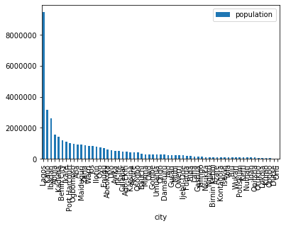

```python
import seaborn as sns

ng_df4.plot( x='city', y='population', kind='bar')
```

# D. Geomapping and map creation using folium

The data frame was subjected to geo mapping after which the map of th two major cities of interest were created as below.

```python
address = 'Lagos, LG'

geolocator = Nominatim(user_agent="LG_explorer")
location = geolocator.geocode(address)
latitude = location.latitude
longitude = location.longitude
#print('The geograpical coordinate of Lagos are {}, {}.'.format(latitude, longitude)

lagos_map = folium.Map(location=[latitude, longitude], zoom_start=11)

# add markers to map
for latitude, longitude, label in zip(ng_df4['latitude'], ng_df4['longitude'], ng_df4['city']):
    label = folium.Popup(label)
    folium.CircleMarker(
        [latitude, longitude],
        radius=5,
        popup=label,
        color='blue',
        fill_color='#3186cc',
        fill_opacity=0.7).add_to(lagos_map)

lagos_map
```

[interactive chart not shown]

```python
address = 'Abuja, AB'

geolocator = Nominatim(user_agent="NG_explorer")
location = geolocator.geocode(address)
latitude = location.latitude
longitude = location.longitude
#print('The geograpical coordinate of Lagos are {}, {}.'.format(latitude, longitude)

abuja_map = folium.Map(location=[latitude, longitude], zoom_start=11)

# add markers to map
for lat, lng, label in zip(ng_df4['latitude'], ng_df4['longitude'], ng_df4['city']):
    label = folium.Popup(label)
    folium.CircleMarker(
        [lat, lng],
        radius=5,
        popup=label,
        color='blue',
        fill_color='#3186cc',
        fill_opacity=0.7).add_to(abuja_map)

abuja_map
```

[interactive chart not shown]

```python
# Get the lagos data
lagos_df = ng_df4.loc[ng_df4['city'] == 'Lagos']
lagos_df
```

|  | city | population | latitude | longitude |
| --- | --- | --- | --- | --- |
| 0 | Lagos | 9466000.0 | 6.454066 | 3.394673 |

```python
neighborhood_latitude = lagos_df.loc[0]['latitude']
neighborhood_longitude = lagos_df.loc[0]['longitude']
```

```python
LIMIT = 100 # limit of number of venues returned by Foursquare API

radius = 500 # define radius

 # create URL
url = 'https://api.foursquare.com/v2/venues/explore?&client_id={}&client_secret={}&v={}&ll={},{}&radius={}&limit={}'.format(
    CLIENT_ID,
    CLIENT_SECRET,
    VERSION,
    neighborhood_latitude,
    neighborhood_longitude,
    radius,
    LIMIT)
#url # display URL
```

Get th json data

```python
results = requests.get(url).json()
#results
```

```python
# function that extracts the category of the venue
def get_category_type(row):
    try:
        categories_list = row['categories']
    except:
        categories_list = row['venue.categories']

    if len(categories_list) == 0:
        return None
    else:
        return categories_list[0]['name']
```

```python
venues = results['response']['groups'][0]['items']
#venues
```

[output not shown]

```python
nearby_venues = json_normalize(venues) # flatten JSON
nearby_venues
```

|  | referralId | reasons.count | reasons.items | venue.id | venue.name | venue.location.address | venue.location.lat | venue.location.lng | venue.location.labeledLatLngs | venue.location.distance | venue.location.cc | venue.location.city | venue.location.state | venue.location.country | venue.location.formattedAddress | venue.categories | venue.photos.count | venue.photos.groups | venue.location.crossStreet |
| --- | --- | --- | --- | --- | --- | --- | --- | --- | --- | --- | --- | --- | --- | --- | --- | --- | --- | --- | --- |
| 0 | e-0-50ba3f00e4b0c78358420c87-0 | 0 | [{'summary': 'This spot is popular', 'type': '... | 50ba3f00e4b0c78358420c87 | Campos Stadium | Campos Street | 6.451098 | 3.394655 | [{'label': 'display', 'lat': 6.451097614372146... | 330 | NG | Lagos Island | Lagos | Nigeria | [Campos Street, Lagos Island, Lagos, Nigeria] | [{'id': '4cce455aebf7b749d5e191f5', 'name': 'S... | 0 | [] | NaN |
| 1 | e-0-4d1744d9816af04df50f4ec2-1 | 0 | [{'summary': 'This spot is popular', 'type': '... | 4d1744d9816af04df50f4ec2 | Sweet Sensation | 27 Kakawa St | 6.453180 | 3.391035 | [{'label': 'display', 'lat': 6.45318023620573,... | 414 | NG | Lagos | Lagos | Nigeria | [27 Kakawa St, Lagos, Lagos, Nigeria] | [{'id': '4bf58dd8d48988d16e941735', 'name': 'F... | 0 | [] | NaN |
| 2 | e-0-500f3818e4b0bc9a81d55c76-2 | 0 | [{'summary': 'This spot is popular', 'type': '... | 500f3818e4b0bc9a81d55c76 | Geez Lounge | Lekki phase 1 | 6.453056 | 3.395833 | [{'label': 'display', 'lat': 6.4530556, 'lng':... | 170 | NG | Lagos | Lagos | Nigeria | [Lekki phase 1 (Opp pavilion lounge), Lagos, L... | [{'id': '4bf58dd8d48988d121941735', 'name': 'L... | 0 | [] | Opp pavilion lounge |
| 3 | e-0-4f512e56e4b0336532a01a26-3 | 0 | [{'summary': 'This spot is popular', 'type': '... | 4f512e56e4b0336532a01a26 | Astroturf | NaN | 6.451066 | 3.394763 | [{'label': 'display', 'lat': 6.451065922770811... | 334 | NG | Lagos | Lagos | Nigeria | [Lagos, Lagos, Nigeria] | [{'id': '4cce455aebf7b749d5e191f5', 'name': 'S... | 0 | [] | NaN |

```python
# filter columns
filtered_columns = ['venue.name', 'venue.categories', 'venue.location.lat', 'venue.location.lng']
nearby_venues = nearby_venues.loc[:, filtered_columns]

# filter the category for each row
nearby_venues['venue.categories'] = nearby_venues.apply(get_category_type, axis=1)

# clean columns
nearby_venues.columns = [col.split(".")[-1] for col in nearby_venues.columns]

nearby_venues
```

|  | name | categories | lat | lng |
| --- | --- | --- | --- | --- |
| 0 | Campos Stadium | Soccer Field | 6.451098 | 3.394655 |
| 1 | Sweet Sensation | Fast Food Restaurant | 6.453180 | 3.391035 |
| 2 | Geez Lounge | Lounge | 6.453056 | 3.395833 |
| 3 | Astroturf | Soccer Field | 6.451066 | 3.394763 |

```python
print('{} venues were returned by Foursquare.'.format(nearby_venues.shape[0]))
```

```
4 venues were returned by Foursquare.
```

```python
def getNearbyVenues(names, latitudes, longitudes, radius=500):

    venues_list=[]
    for name, lat, lng in zip(names, latitudes, longitudes):
        print(name)

        # create the API request URL
        url = 'https://api.foursquare.com/v2/venues/explore?&client_id={}&client_secret={}&v={}&ll={},{}&radius={}&limit={}'.format(
            CLIENT_ID,
            CLIENT_SECRET,
            VERSION,
            lat,
            lng,
            radius,
            LIMIT)

        # make the GET request
        results = requests.get(url).json()["response"]['groups'][0]['items']


         # return only relevant information for each nearby venue
        venues_list.append([(
            name,
            lat,
            lng,
            v['venue']['name'],
            v['venue']['location']['lat'],
            v['venue']['location']['lng'],
            v['venue']['categories'][0]['name']) for v in results])
        nearby_venues = pd.DataFrame([item for venue_list in venues_list for item in venue_list])
    nearby_venues.columns = ['Neighborhood',
                  'Neighborhood Latitude',
                  'Neighborhood Longitude',
                  'Venue',
                  'Venue Latitude',
                  'Venue Longitude',
                  'Venue Category']

    return(nearby_venues)
```

```python
lagos_df
```

|  | city | population | latitude | longitude |
| --- | --- | --- | --- | --- |
| 0 | Lagos | 9466000.0 | 6.454066 | 3.394673 |

### E. Results / Discussions

1. For someone looking to open a restaurant I will recommend Lagos city, around Campos standium.

Reasons:

Lagos has a large population and implicitly, a large population translates to higher clientele.

Lagos is situated by the sea and has seaports and airports and will have a lot of people in transit and tourism.

1. For a contractor trying to start his own business

I will still recommend lagos city for the same reasons proffered above, population. From the data and plot, Lagos city's population is not comparable to any other city in Nigeria, in size and people will like to build either for renting our for personl use or both.

## F. Conclusions

From the results of my analysis, I will recommend the city of Lagos in Nigeria as the most fertile business ground for someone planning to open restaurant as well as for an aspiring contractor. Its rich road network, seaports as well as airports and dense population is a plus for businesses.

Thank you.